# Kernel Matrix

Mauro Camara Escudero

11/18/2019

$\DeclareMathOperator*{\argmin}{arg\,min}$ $\DeclareMathOperator*{\argmax}{arg\,max}$ $\newcommand{\var}{\mathrm{Var}}$

Suppose that we have a matrix $X\in\mathbb{R}^{n\times d}$ whose rows represent one observation of $d$ features, and whose columns represent all $n$ observations of a particular feature.
$$\begin{pmatrix}
x_{11} & x_{12} & \cdots & x_{1d} \\
x_{21} & x_{22} & \cdots & x_{2d} \\
\vdots & \vdots & \ddots & \vdots \\
x_{n1} & x_{n2} & \cdots & x_{nd}
\end{pmatrix} =
\begin{pmatrix}
\boldsymbol{\mathbf{x}}_1^\top \\
\boldsymbol{\mathbf{x}}_2^\top \\
\vdots \\
\boldsymbol{\mathbf{x}}_n^\top
\end{pmatrix} \qquad \text{where } \boldsymbol{\mathbf{x}}_i\in\mathbb{R}^{d\times 1} \quad \forall \, i\in\{1, \ldots, n\}$$
We want to use the kernel function
$$k(\boldsymbol{\mathbf{x}}_i, \boldsymbol{\mathbf{x}}_j) := \exp\left(- \frac{\parallel\boldsymbol{\mathbf{x}}_i - \boldsymbol{\mathbf{x}}_j\parallel^2}{\sigma^2}\right)$$
to create the kernel matrix $K$ whose entries are $[K]_{ij} :=k(\boldsymbol{\mathbf{x}}_i, \boldsymbol{\mathbf{x}}_j)$. To vectorize this operation, we aim to create a matrix containing all the squared norms of the difference between the vectors
$$D =
\begin{pmatrix}
\parallel \boldsymbol{\mathbf{x}}_1 - \boldsymbol{\mathbf{x}}_1 \parallel^2 & \parallel \boldsymbol{\mathbf{x}}_1 - \boldsymbol{\mathbf{x}}_2 \parallel^2 & \cdots & \parallel \boldsymbol{\mathbf{x}}_1 - \boldsymbol{\mathbf{x}}_n \parallel^2 \\
\parallel \boldsymbol{\mathbf{x}}_2 - \boldsymbol{\mathbf{x}}_1 \parallel^2 & \parallel \boldsymbol{\mathbf{x}}_2 - \boldsymbol{\mathbf{x}}_2 \parallel^2 & \cdots & \parallel \boldsymbol{\mathbf{x}}_2 - \boldsymbol{\mathbf{x}}_n \parallel^2 \\
\vdots & \vdots & \ddots & \vdots \\
\parallel \boldsymbol{\mathbf{x}}_n - \boldsymbol{\mathbf{x}}_1 \parallel^2 & \parallel \boldsymbol{\mathbf{x}}_n - \boldsymbol{\mathbf{x}}_2 \parallel^2 & \cdots & \parallel \boldsymbol{\mathbf{x}}_n - \boldsymbol{\mathbf{x}}_n \parallel^2
\end{pmatrix}$$
so that then we can simply run this:

```r
exp(- D / sigma_sq)
```

Notice that we can rewrite the norm of the difference between two vectors $\boldsymbol{\mathbf{x}}_i$ and $\boldsymbol{\mathbf{x}}_j$ as follows
$$\parallel \boldsymbol{\mathbf{x}}_i - \boldsymbol{\mathbf{x}}_j \parallel^2 = (\boldsymbol{\mathbf{x}}_i - \boldsymbol{\mathbf{x}}_j)^\top (\boldsymbol{\mathbf{x}}_i - \boldsymbol{\mathbf{x}}_j) = \boldsymbol{\mathbf{x}}_i^\top\boldsymbol{\mathbf{x}}_i - 2\boldsymbol{\mathbf{x}}_i^\top \boldsymbol{\mathbf{x}}_j + \boldsymbol{\mathbf{x}}_j^\top\boldsymbol{\mathbf{x}}_j$$
Broadcasting this, we can rewrite the matrix $D$ as
$$D =
\begin{pmatrix}
\boldsymbol{\mathbf{x}}_{1}^\top\boldsymbol{\mathbf{x}}_{1} - 2\boldsymbol{\mathbf{x}}_{1}^\top \boldsymbol{\mathbf{x}}_{1} + \boldsymbol{\mathbf{x}}_{1}^\top\boldsymbol{\mathbf{x}}_{1} & \quad\boldsymbol{\mathbf{x}}_{1}^\top\boldsymbol{\mathbf{x}}_{1} - 2\boldsymbol{\mathbf{x}}_{1}^\top \boldsymbol{\mathbf{x}}_{2} + \boldsymbol{\mathbf{x}}_{2}^\top\boldsymbol{\mathbf{x}}_{2} & \quad\cdots & \quad\boldsymbol{\mathbf{x}}_{1}^\top\boldsymbol{\mathbf{x}}_{1} - 2\boldsymbol{\mathbf{x}}_{1}^\top \boldsymbol{\mathbf{x}}_{n} + \boldsymbol{\mathbf{x}}_{n}^\top\boldsymbol{\mathbf{x}}_{n}\\
\boldsymbol{\mathbf{x}}_{2}^\top\boldsymbol{\mathbf{x}}_{2} - 2\boldsymbol{\mathbf{x}}_{2}^\top \boldsymbol{\mathbf{x}}_{1} + \boldsymbol{\mathbf{x}}_{1}^\top\boldsymbol{\mathbf{x}}_{1} & \quad\boldsymbol{\mathbf{x}}_{2}^\top\boldsymbol{\mathbf{x}}_{2} - 2\boldsymbol{\mathbf{x}}_{2}^\top \boldsymbol{\mathbf{x}}_{2} + \boldsymbol{\mathbf{x}}_{2}^\top\boldsymbol{\mathbf{x}}_{2} & \quad\cdots & \quad\boldsymbol{\mathbf{x}}_{2}^\top\boldsymbol{\mathbf{x}}_{2} - 2\boldsymbol{\mathbf{x}}_{2}^\top \boldsymbol{\mathbf{x}}_{n} + \boldsymbol{\mathbf{x}}_{n}^\top\boldsymbol{\mathbf{x}}_{n}\\
\vdots & \quad\vdots & \quad\ddots & \quad\vdots \\
\boldsymbol{\mathbf{x}}_{n}^\top\boldsymbol{\mathbf{x}}_{n} - 2\boldsymbol{\mathbf{x}}_{n}^\top \boldsymbol{\mathbf{x}}_{1} + \boldsymbol{\mathbf{x}}_{1}^\top\boldsymbol{\mathbf{x}}_{1} & \quad\boldsymbol{\mathbf{x}}_{n}^\top\boldsymbol{\mathbf{x}}_{n} - 2\boldsymbol{\mathbf{x}}_{n}^\top \boldsymbol{\mathbf{x}}_{2} + \boldsymbol{\mathbf{x}}_{2}^\top\boldsymbol{\mathbf{x}}_{2} & \quad\cdots & \quad\boldsymbol{\mathbf{x}}_{n}^\top\boldsymbol{\mathbf{x}}_{n} - 2\boldsymbol{\mathbf{x}}_{n}^\top \boldsymbol{\mathbf{x}}_{n} + \boldsymbol{\mathbf{x}}_{n}^\top\boldsymbol{\mathbf{x}}_{n}
\end{pmatrix}$$
This can now be split into three matrices, where we can notice that the third matrix is nothing but the transpose of the first.
$$D =
\begin{pmatrix}
\boldsymbol{\mathbf{x}}_1^\top\boldsymbol{\mathbf{x}}_1 & \boldsymbol{\mathbf{x}}_1^\top\boldsymbol{\mathbf{x}}_1 & \cdots & \boldsymbol{\mathbf{x}}_1^\top\boldsymbol{\mathbf{x}}_1\\
\boldsymbol{\mathbf{x}}_2^\top\boldsymbol{\mathbf{x}}_2 & \boldsymbol{\mathbf{x}}_2^\top\boldsymbol{\mathbf{x}}_2 & \cdots & \boldsymbol{\mathbf{x}}_2^\top\boldsymbol{\mathbf{x}}_2 \\
\vdots & \vdots & \ddots & \vdots\\
\boldsymbol{\mathbf{x}}_n^\top\boldsymbol{\mathbf{x}}_n & \boldsymbol{\mathbf{x}}_n^\top\boldsymbol{\mathbf{x}}_n & \cdots & \boldsymbol{\mathbf{x}}_n^\top\boldsymbol{\mathbf{x}}_n
\end{pmatrix}
-2
\begin{pmatrix}
\boldsymbol{\mathbf{x}}_{1}^\top\boldsymbol{\mathbf{x}}_{1} & \boldsymbol{\mathbf{x}}_{1}^\top\boldsymbol{\mathbf{x}}_{2} & \cdots & \boldsymbol{\mathbf{x}}_{1}^\top\boldsymbol{\mathbf{x}}_{n} \\
\boldsymbol{\mathbf{x}}_{2}^\top\boldsymbol{\mathbf{x}}_{1} & \boldsymbol{\mathbf{x}}_{2}^\top\boldsymbol{\mathbf{x}}_{2} & \cdots & \boldsymbol{\mathbf{x}}_{2}^\top\boldsymbol{\mathbf{x}}_{n} \\
\vdots & \vdots & \ddots & \vdots \\
\boldsymbol{\mathbf{x}}_{n}^\top\boldsymbol{\mathbf{x}}_{1} & \boldsymbol{\mathbf{x}}_{n}^\top\boldsymbol{\mathbf{x}}_{2} & \cdots & \boldsymbol{\mathbf{x}}_{n}^\top\boldsymbol{\mathbf{x}}_{n}
\end{pmatrix}
+
\begin{pmatrix}
\boldsymbol{\mathbf{x}}_{1}^\top\boldsymbol{\mathbf{x}}_{1} & \boldsymbol{\mathbf{x}}_{2}^\top\boldsymbol{\mathbf{x}}_{2} & \cdots & \boldsymbol{\mathbf{x}}_{n}^\top\boldsymbol{\mathbf{x}}_{n} \\
\boldsymbol{\mathbf{x}}_{1}^\top\boldsymbol{\mathbf{x}}_{1} & \boldsymbol{\mathbf{x}}_{2}^\top\boldsymbol{\mathbf{x}}_{2} & \cdots & \boldsymbol{\mathbf{x}}_{n}^\top\boldsymbol{\mathbf{x}}_{n} \\
\vdots & \vdots & \ddots & \vdots \\
\boldsymbol{\mathbf{x}}_{1}^\top\boldsymbol{\mathbf{x}}_{1} & \boldsymbol{\mathbf{x}}_{2}^\top\boldsymbol{\mathbf{x}}_{2} & \cdots & \boldsymbol{\mathbf{x}}_{n}^\top\boldsymbol{\mathbf{x}}_{n}
\end{pmatrix}$$
The key is not to notice that we can obtain the middle matrix from $X$ with a simple operation:
$$XX^\top =
\begin{pmatrix}
\boldsymbol{\mathbf{x}}_1^\top \\
\boldsymbol{\mathbf{x}}_2^\top \\
\vdots \\
\boldsymbol{\mathbf{x}}_n^\top
\end{pmatrix}
\begin{pmatrix}
\boldsymbol{\mathbf{x}}_1 & \boldsymbol{\mathbf{x}}_2 & \cdots & \boldsymbol{\mathbf{x}}_n
\end{pmatrix}
=
\begin{pmatrix}
\boldsymbol{\mathbf{x}}_{1}^\top\boldsymbol{\mathbf{x}}_{1} & \boldsymbol{\mathbf{x}}_{1}^\top\boldsymbol{\mathbf{x}}_{2} & \cdots & \boldsymbol{\mathbf{x}}_{1}^\top\boldsymbol{\mathbf{x}}_{n} \\
\boldsymbol{\mathbf{x}}_{2}^\top\boldsymbol{\mathbf{x}}_{1} & \boldsymbol{\mathbf{x}}_{2}^\top\boldsymbol{\mathbf{x}}_{2} & \cdots & \boldsymbol{\mathbf{x}}_{2}^\top\boldsymbol{\mathbf{x}}_{n} \\
\vdots & \vdots & \ddots & \vdots \\
\boldsymbol{\mathbf{x}}_{n}^\top\boldsymbol{\mathbf{x}}_{1} & \boldsymbol{\mathbf{x}}_{n}^\top\boldsymbol{\mathbf{x}}_{2} & \cdots & \boldsymbol{\mathbf{x}}_{n}^\top\boldsymbol{\mathbf{x}}_{n}
\end{pmatrix}$$
and then the first matrix can be obtained as follows
$$\begin{pmatrix}
1 \\
1 \\
\vdots \\
1
\end{pmatrix}_{n\times 1}
\begin{pmatrix}
\boldsymbol{\mathbf{x}}_{1}^\top\boldsymbol{\mathbf{x}}_{1} & \boldsymbol{\mathbf{x}}_{2}^\top\boldsymbol{\mathbf{x}}_{2} & \cdots & \boldsymbol{\mathbf{x}}_{n}^\top\boldsymbol{\mathbf{x}}_{n}
\end{pmatrix}_{1\times n}
=
\begin{pmatrix}
\boldsymbol{\mathbf{x}}_1^\top\boldsymbol{\mathbf{x}}_1 & \boldsymbol{\mathbf{x}}_1^\top\boldsymbol{\mathbf{x}}_1 & \cdots & \boldsymbol{\mathbf{x}}_1^\top\boldsymbol{\mathbf{x}}_1\\
\boldsymbol{\mathbf{x}}_2^\top\boldsymbol{\mathbf{x}}_2 & \boldsymbol{\mathbf{x}}_2^\top\boldsymbol{\mathbf{x}}_2 & \cdots & \boldsymbol{\mathbf{x}}_2^\top\boldsymbol{\mathbf{x}}_2 \\
\vdots & \vdots & \ddots & \vdots\\
\boldsymbol{\mathbf{x}}_n^\top\boldsymbol{\mathbf{x}}_n & \boldsymbol{\mathbf{x}}_n^\top\boldsymbol{\mathbf{x}}_n & \cdots & \boldsymbol{\mathbf{x}}_n^\top\boldsymbol{\mathbf{x}}_n
\end{pmatrix}$$
where
$$\text{diag}\left[
\begin{pmatrix}
\boldsymbol{\mathbf{x}}_{1}^\top\boldsymbol{\mathbf{x}}_{1} & \boldsymbol{\mathbf{x}}_{1}^\top\boldsymbol{\mathbf{x}}_{2} & \cdots & \boldsymbol{\mathbf{x}}_{1}^\top\boldsymbol{\mathbf{x}}_{n} \\
\boldsymbol{\mathbf{x}}_{2}^\top\boldsymbol{\mathbf{x}}_{1} & \boldsymbol{\mathbf{x}}_{2}^\top\boldsymbol{\mathbf{x}}_{2} & \cdots & \boldsymbol{\mathbf{x}}_{2}^\top\boldsymbol{\mathbf{x}}_{n} \\
\vdots & \vdots & \ddots & \vdots \\
\boldsymbol{\mathbf{x}}_{n}^\top\boldsymbol{\mathbf{x}}_{1} & \boldsymbol{\mathbf{x}}_{n}^\top\boldsymbol{\mathbf{x}}_{2} & \cdots & \boldsymbol{\mathbf{x}}_{n}^\top\boldsymbol{\mathbf{x}}_{n}
\end{pmatrix}
\right]
=
\begin{pmatrix}
\boldsymbol{\mathbf{x}}_{1}^\top\boldsymbol{\mathbf{x}}_{1} & \boldsymbol{\mathbf{x}}_{2}^\top\boldsymbol{\mathbf{x}}_{2} & \cdots & \boldsymbol{\mathbf{x}}_{n}^\top\boldsymbol{\mathbf{x}}_{n}
\end{pmatrix}_{1\times n}$$
Therefore we can write a function to calculate the `rbf` kernel matrix as follows in `R`:

```r
kernel_matrix <- function(X, sigmasq){
  # Find second matrix
  Y <- tcrossprod(X)
  # Find first matrix (whose transpose is the second)
  Z <- matrix(1, nrow(X)) %*% diag(Y)
  return(exp(-(Z - 2*Y + t(Z)) / sigmasq))
}
```

We can try this out on a simple matrix

```r
X <- matrix(1:20, 4, 5)
X
```

```
##      [,1] [,2] [,3] [,4] [,5]
## [1,]    1    5    9   13   17
## [2,]    2    6   10   14   18
## [3,]    3    7   11   15   19
## [4,]    4    8   12   16   20
```

which gives

```r
kernel_matrix(X, 1)
```

```
##              [,1]         [,2]         [,3]         [,4]
## [1,] 1.000000e+00 6.737947e-03 2.061154e-09 2.862519e-20
## [2,] 6.737947e-03 1.000000e+00 6.737947e-03 2.061154e-09
## [3,] 2.061154e-09 6.737947e-03 1.000000e+00 6.737947e-03
## [4,] 2.862519e-20 2.061154e-09 6.737947e-03 1.000000e+00
```

and it makes sense because it has `1` on the diagonals, it is symmetric and the values corresponding to the furthest away points have the smallest values.

```r
kernel_matrix <- function(X){
  # Find second matrix
  Y <- tcrossprod(X)
  # Find first matrix (whose transpose is the second)
  Z <- matrix(1, nrow(X)) %*% diag(Y)
  return(exp(-(Z - 2*Y + t(Z)) / median(Y)))
}
kernel_matrix(X)
```

```
##           [,1]      [,2]      [,3]      [,4]
## [1,] 1.0000000 0.9929329 0.9720298 0.9381647
## [2,] 0.9929329 1.0000000 0.9929329 0.9720298
## [3,] 0.9720298 0.9929329 1.0000000 0.9929329
## [4,] 0.9381647 0.9720298 0.9929329 1.0000000
```

## Making predictions

Recall that our formula for predicting the output of a new input $\widehat{\boldsymbol{\mathbf{x}}}$ is
$$f(\widehat{\boldsymbol{\mathbf{x}}}) = \boldsymbol{\mathbf{k}}(\boldsymbol{\mathbf{K}}+ \lambda I)^{-1}\boldsymbol{\mathbf{y}}$$
where
$$\boldsymbol{\mathbf{k}}:=\left(k(\widehat{\boldsymbol{\mathbf{x}}}, \boldsymbol{\mathbf{x}}_1), \ldots, k(\widehat{\boldsymbol{\mathbf{x}}}, \boldsymbol{\mathbf{x}}_n)\right)\in\mathbb{R}^{1\times n}$$
Now suppose that instead we get a whole bunch of testing data points
$$\widehat{X}:=
\begin{pmatrix}
\widehat{\boldsymbol{\mathbf{x}}}_1^\top \\
\widehat{\boldsymbol{\mathbf{x}}}_2^\top \\
\vdots \\
\widehat{\boldsymbol{\mathbf{x}}}_m^\top
\end{pmatrix}\in\mathbb{R}^{m\times d}$$
Then we can actually construct a vector of predictions as follows
$$\begin{pmatrix}
f(\widehat{\boldsymbol{\mathbf{x}}}_1) \\
f(\widehat{\boldsymbol{\mathbf{x}}}_2) \\
\vdots \\
f(\widehat{\boldsymbol{\mathbf{x}}}_m)
\end{pmatrix}
=
\begin{pmatrix}
\boldsymbol{\mathbf{k}}_1(\boldsymbol{\mathbf{K}}+ \lambda I)^{-1}\boldsymbol{\mathbf{y}}\\
\boldsymbol{\mathbf{k}}_2(\boldsymbol{\mathbf{K}}+ \lambda I)^{-1}\boldsymbol{\mathbf{y}}\\
\vdots \\
\boldsymbol{\mathbf{k}}_m(\boldsymbol{\mathbf{K}}+ \lambda I)^{-1}\boldsymbol{\mathbf{y}}
\end{pmatrix}
=
\begin{pmatrix}
\boldsymbol{\mathbf{k}}_1 \\
\boldsymbol{\mathbf{k}}_2 \\
\vdots \\
\boldsymbol{\mathbf{k}}_m
\end{pmatrix}
(\boldsymbol{\mathbf{K}}+ \lambda I)^{-1}\boldsymbol{\mathbf{y}}=: \widetilde{\boldsymbol{\mathbf{K}}}(\boldsymbol{\mathbf{K}}+ \lambda I)^{-1}\boldsymbol{\mathbf{y}}$$
where
$$\boldsymbol{\mathbf{k}}_i := \left(k(\widehat{\boldsymbol{\mathbf{x}}}_i, \boldsymbol{\mathbf{x}}_1), \ldots, k(\widehat{\boldsymbol{\mathbf{x}}}_i, \boldsymbol{\mathbf{x}}_n)\right) \qquad \text{for } i\in\{1, \ldots, m\}$$
and
$$\widetilde{\boldsymbol{\mathbf{K}}} :=
\begin{pmatrix}
\boldsymbol{\mathbf{k}}_1 \\
\boldsymbol{\mathbf{k}}_2 \\
\vdots \\
\boldsymbol{\mathbf{k}}_m
\end{pmatrix} \in\mathbb{R}^{m\times n}$$
with entries
$$[\widetilde{\boldsymbol{\mathbf{K}}}]_{ij} = k(\widehat{\boldsymbol{\mathbf{x}}}_i, \boldsymbol{\mathbf{x}}_j)$$
In other words, we need to be able to modify our algorithm to give us the following matrix
$$\widetilde{D} =
\begin{pmatrix}
\parallel \widehat{\boldsymbol{\mathbf{x}}}_1 - \boldsymbol{\mathbf{x}}_1 \parallel^2 & \parallel \widehat{\boldsymbol{\mathbf{x}}}_1 - \boldsymbol{\mathbf{x}}_2 \parallel^2 & \cdots & \parallel \widehat{\boldsymbol{\mathbf{x}}}_1 - \boldsymbol{\mathbf{x}}_n \parallel^2\\
\parallel \widehat{\boldsymbol{\mathbf{x}}}_2 - \boldsymbol{\mathbf{x}}_1 \parallel^2 & \parallel \widehat{\boldsymbol{\mathbf{x}}}_2 - \boldsymbol{\mathbf{x}}_2 \parallel^2 & \cdots & \parallel \widehat{\boldsymbol{\mathbf{x}}}_2 - \boldsymbol{\mathbf{x}}_n \parallel^2\\
\vdots & \vdots & \ddots & \vdots \\
\parallel \widehat{\boldsymbol{\mathbf{x}}}_m - \boldsymbol{\mathbf{x}}_1 \parallel^2 & \parallel \widehat{\boldsymbol{\mathbf{x}}}_m - \boldsymbol{\mathbf{x}}_2 \parallel^2 & \cdots & \parallel \widehat{\boldsymbol{\mathbf{x}}}_m - \boldsymbol{\mathbf{x}}_n \parallel^2
\end{pmatrix}$$
which leads to
$$\widetilde{D} =
\begin{pmatrix}
\widehat{\boldsymbol{\mathbf{x}}}_1^\top\widehat{\boldsymbol{\mathbf{x}}}_1 & \widehat{\boldsymbol{\mathbf{x}}}_1^\top\widehat{\boldsymbol{\mathbf{x}}}_1 & \cdots & \widehat{\boldsymbol{\mathbf{x}}}_1^\top\widehat{\boldsymbol{\mathbf{x}}}_1\\
\widehat{\boldsymbol{\mathbf{x}}}_2^\top\widehat{\boldsymbol{\mathbf{x}}}_2 & \widehat{\boldsymbol{\mathbf{x}}}_2^\top\widehat{\boldsymbol{\mathbf{x}}}_2 & \cdots & \widehat{\boldsymbol{\mathbf{x}}}_2^\top\widehat{\boldsymbol{\mathbf{x}}}_2 \\
\vdots & \vdots & \ddots & \vdots\\
\widehat{\boldsymbol{\mathbf{x}}}_n^\top\widehat{\boldsymbol{\mathbf{x}}}_n & \widehat{\boldsymbol{\mathbf{x}}}_n^\top\widehat{\boldsymbol{\mathbf{x}}}_n & \cdots & \widehat{\boldsymbol{\mathbf{x}}}_n^\top\widehat{\boldsymbol{\mathbf{x}}}_n
\end{pmatrix}
-2
\begin{pmatrix}
\widehat{\boldsymbol{\mathbf{x}}}_{1}^\top\boldsymbol{\mathbf{x}}_{1} & \widehat{\boldsymbol{\mathbf{x}}}_{1}^\top\boldsymbol{\mathbf{x}}_{2} & \cdots & \widehat{\boldsymbol{\mathbf{x}}}_{1}^\top\boldsymbol{\mathbf{x}}_{n} \\
\widehat{\boldsymbol{\mathbf{x}}}_{2}^\top\boldsymbol{\mathbf{x}}_{1} & \widehat{\boldsymbol{\mathbf{x}}}_{2}^\top\boldsymbol{\mathbf{x}}_{2} & \cdots & \widehat{\boldsymbol{\mathbf{x}}}_{2}^\top\boldsymbol{\mathbf{x}}_{n} \\
\vdots & \vdots & \ddots & \vdots \\
\widehat{\boldsymbol{\mathbf{x}}}_{n}^\top\boldsymbol{\mathbf{x}}_{1} & \widehat{\boldsymbol{\mathbf{x}}}_{n}^\top\boldsymbol{\mathbf{x}}_{2} & \cdots & \widehat{\boldsymbol{\mathbf{x}}}_{n}^\top\boldsymbol{\mathbf{x}}_{n}
\end{pmatrix}
+
\begin{pmatrix}
\boldsymbol{\mathbf{x}}_{1}^\top\boldsymbol{\mathbf{x}}_{1} & \boldsymbol{\mathbf{x}}_{2}^\top\boldsymbol{\mathbf{x}}_{2} & \cdots & \boldsymbol{\mathbf{x}}_{n}^\top\boldsymbol{\mathbf{x}}_{n} \\
\boldsymbol{\mathbf{x}}_{1}^\top\boldsymbol{\mathbf{x}}_{1} & \boldsymbol{\mathbf{x}}_{2}^\top\boldsymbol{\mathbf{x}}_{2} & \cdots & \boldsymbol{\mathbf{x}}_{n}^\top\boldsymbol{\mathbf{x}}_{n} \\
\vdots & \vdots & \ddots & \vdots \\
\boldsymbol{\mathbf{x}}_{1}^\top\boldsymbol{\mathbf{x}}_{1} & \boldsymbol{\mathbf{x}}_{2}^\top\boldsymbol{\mathbf{x}}_{2} & \cdots & \boldsymbol{\mathbf{x}}_{n}^\top\boldsymbol{\mathbf{x}}_{n}
\end{pmatrix}$$
Luckily, we can do this by adjusting our original `kernel_matrix` function

```r
kernel_matrix <- function(X, Y=NULL, sigmasq=NULL){
  if (is.null(Y)){
    Y <- X  # TODO: This might be risky for big matrices. How does R copy work? Maybe split the code into two?
  }
  n <- nrow(X)
  m <- nrow(Y)
  # Find three matrices above
  Xnorm <- matrix(apply(X^2, 1, sum), n, m)
  Ynorm <- matrix(apply(Y^2, 1, sum), n, m, byrow=TRUE)
  XY <- tcrossprod(X, Y)
  # TODO: In this case do we use median of XY? If we are using it for prediction
  # I think sigmasq should be found only from training set, not from testing set.
  # Therefore we should pass sigmasq as a parameter in this function, and should be calculated
  # beforehand.
  if (is.null(sigmasq)) {
    # We calculate sigmasq from training data and return it to be used for prediction
    sigmasq <- median(XY)
    return(list(
        exp(-(Xnorm - 2*XY + Ynorm) / sigmasq),
        sigmasq
        )
      )
  } else {
    return(exp(-(Xnorm - 2*XY + Ynorm) / sigmasq))
  }
}
```

At this point we’re ready to construct a prediction function.

```r
predict <- function(Xhat, X, y, reg_coef=0){
  # find K tilde and K
  Kstuff <- kernel_matrix(X)
  K <- Kstuff[[1]]
  sigmasq <- Kstuff[[2]]
  Ktilde <- kernel_matrix(Xhat, X, sigmasq = sigmasq)
  # Invert K + lambda*I where lambda=reg_coef and use Ktilde*(K+lambdaI)^{-1}y
  return(Ktilde %*% solve(K + reg_coef*diag(nrow(X))) %*% y)
}
```

## Get real data and perform regression

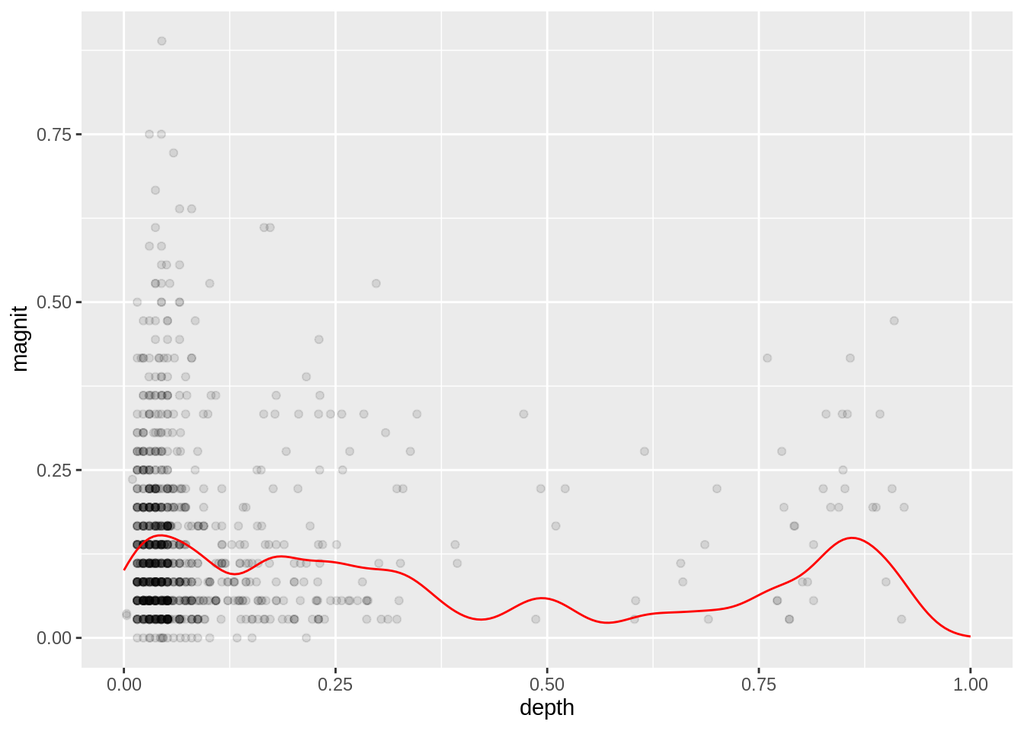

```r
library(ggplot2)
source("data_preparation.R")
# Restrict to only n datapoints, use only depth
n = 1000
m = 200
df <- get_data()[1:n, c("depth", "magnit")]
X <- as.matrix(df$depth)
y <- as.matrix(df$magnit)
# Get predictions
Xhat <- as.matrix(seq(0, 1, length.out=m)) #X
yhat <- predict(Xhat, X, y, reg_coef=10)
df_pred <- data.frame(depth=Xhat, pred=yhat)
# Plot stuff
ggplot(data=df, aes(x=depth, y=magnit)) +
  geom_point(alpha=0.1) +
  geom_line(data=df_pred, aes(x=depth, y=pred), color='red')
```

We can see how it performs on the whole dataset

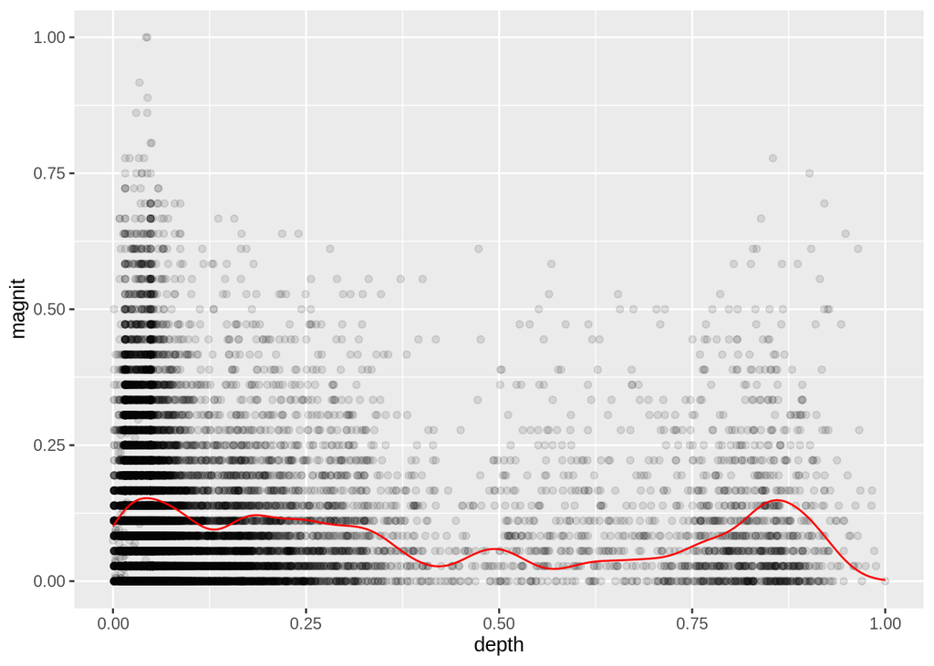

```r
all_data <- get_data()[, c("depth", "magnit")]
ggplot(data=all_data, aes(x=depth, y=magnit)) +
  geom_point(alpha=0.1) +
  geom_line(data=df_pred, aes(x=depth, y=pred), color='red')
```